# ผู้จัดทำ

- นายพัสสน แซ่โจว รหัส 64543206037-6

# k-Nearest Neighbor (kNN) exercise

**kNN classifier ประกอบไปด้วย 2 ขั้นตอนหลัก คือ:**

- **ในขั้นการ train** จะทำเพียงเก็บ (จำ) ข้อมูล training set ทั้งหมดไว้ในตัวแปร
- **ในขั้นการ predict** อัลกอริทึม kNN ทำนายค่า label ของแต่ละ test image ตาม majority vote ของเพื่อนบ้าน โดยมี 3 ขั้นตอนย่อยดังนี้
  1. คำนวณหาระยะห่าง (L2 distance) ระหว่าง test image และ train image ทุกคู่ภาพ
  2. สำหรับแต่ละ test image เราจะหาภาพ train image ที่มีค่า distance น้อยที่สุด k ภาพ (distance น้อย = ที่มีลักษณะใกล้เคียงที่สุด)
  3. ตอบ label ตาม majority vote ของ k ภาพดังกล่าว

```python
# โค้ด setup ต่างๆ
import random
import numpy as np
import matplotlib.pyplot as plt

%matplotlib inline
plt.rcParams['figure.figsize'] = (5.0, 4.0) # set default size of plots
plt.rcParams['image.interpolation'] = 'nearest'
plt.rcParams['image.cmap'] = 'gray_r'

%reload_ext autoreload
%autoreload 2
```

### จง implement ฟังก์ชันสำหรับ kNN ต่อไปนี้

1. **train(X, y)** มีหน้าที่จำข้อมูล training set เก็บไว้ในตัวแปร
2. **predict(X, k)** มีหน้าที่ทำนาย label ของข้อมูลชุด test โดยใช้เพื่อนบ้านที่ใกล้ที่สุด k ตัว
3. **compute_distances(X)** มีหน้าที่คำนวณระยะห่างระหว่างทุกคู่ภาพ train และ test images โดยเราจะเก็บค่าระยะห่างทั้งหมดไว้ใน distance matrix เช่น สมมติว่าเรามี **1000** training images และมี **200** test images เราจะได้ distance matrix ที่มีขนาด **200 x 1000** โดยที่แต่ละค่าใน matrix ณ ตำแหน่ง (i,j) จะเก็บค่าระยะห่างระหว่าง i-th test และ j-th train image

**หมายเหตุ**

- การคำนวณ L2 distance เป็นตามสมการ $ d_2(I_1,I_2) = \lVert I_1 - I_2 \rVert_2 = \sqrt{\sum_p{(I_1^p - I_2^p)^2}} $

```python
X_train = []
y_train = []

def train(X, y):
    """
    จำข้อมูลชุด train ทั้งหมด เก็บไว้ในตัวแปร X_train, y_train
    """
    X_train = X
    y_train = y


def predict(X, k=1): #รับ X_test ที่จะทำนายมา และเพื่อนบ้านที่ใกล้ที่สุด k ตัว
    """
    ทำนาย label ของข้อมูลชุด test

    Inputs:
    - X: ข้อมูลชุด test
    - k: ค่า hyperparameter k ของอัลกอริทึม k-NN

    Returns:
    - y: numpy array ของ label ที่ทำนาย โดยให้ y[i] เก็บค่า label ของภาพที่ i
    """

    dists = compute_distances(X)
    num_test = X.shape[0]
    y_pred = np.zeros(num_test) #จัดเตรียม array 1D ใหม่ 297

    for i in range(num_test):
        # อาเรย์ขนาด k ซึ่งจะเก็บ k nearest neighbors ของข้อมูลชุด test ตัวที่ i
        closest_y = []

        # TODO: ใช้ distance matrix ในการหา k nearest neighbors
        # และใช้ y_train ในการหาค่า label เพื่อนบ้าน k ตัวดังกล่าว
        # เก็บคำตอบไว้ใน closest_y
        # hint: สามารถใช้ฟังก์ชัน numpy.argsort เพื่อหา index ของ distance ที่น้อยที่สุด k ค่า

        sortindex = np.argsort(dists[i]) #หา index ของ distanceที่น้อยที่สุด จากน้อยไปมาก

        for j in range(k):
            closest_y.append(y_train[sortindex[j]]) # หาค่า label เพื่อนบ้านที่ใกล้ที่สุด k ตัว


        # TODO: หา majority vote ของเพื่อนบ้าน k ตัวแล้วเก็บผลลัพธ์ใน y_pred
        # หากเกิดการเสมอกัน ให้เลือก label ที่มีค่าที่น้อยกว่า
        # hint: ในการนับ vote สามารถใช้ฟังก์ชัน numpy.argmax ร่วมกับ numpy.bincount ได้ หรือไม่ก็เขียนด้วย for-loop

        vote = np.argmax(np.bincount(closest_y))
        y_pred[i] = vote

    return y_pred #label ทำนายได้

def compute_distances(X):
    """
    คำนวณระยะห่างระหว่างข้อมูลชุดทดสอบทุกตัว กับข้อมูลชุดฝึกทุกตัว

    Inputs:
    - X: ข้อมูลชุดทดสอบ

    Returns:
    - dists: distance matrix ขนาด (num_test, num_train) ซึ่ง dists[i, j]
    จะเก็บค่าระยะห่างแบบ L2 ระหว่าง test image ภาพที่ i กับ training image ภาพที่ j
    """
    num_test = X.shape[0] #ได้จำนวนภาพทดสอบ
    num_train = X_train.shape[0] #ได้จำนวนภาพเทรน
    dists = np.zeros((num_test, num_train)) #จัดเตรียม array ใหม่ 297 1500

    for i in range(num_test): #num_test
        for j in range(num_train): #num_train
            # TODO: คำนวณหา dists[i,j] โดยพยายามไม่ใช้ loop ซ้อนอีก
            # hint: มีคำสั่ง np.sqrt(), np.sum(), np.square(), np.linalg.norm() ที่ช่วยคำนวณได้

            aftersub = np.subtract(X[i],X_train[j])
            aftersquared = np.square(aftersub)
            aftersum = np.sum(aftersquared)
            aftersqrt = np.sqrt(aftersum)
            dists[i,j] = aftersqrt

            pass

    return dists
```

### จงนำฟังก์ชัน train, predict ที่ implement เรียบร้อยแล้วไปใช้จำแนกภาพกับข้อมูล MNIST และ CIFAR-10

#### 1. เริ่มจากทำการโหลดข้อมูลภาพและ label แบ่งออกเป็นชุด train/test

```python
from sklearn import datasets
digits = datasets.load_digits()
digits.keys()
```

```
dict_keys(['data', 'target', 'frame', 'feature_names', 'target_names', 'images', 'DESCR'])
```

```
Training data shape:  (1500, 8, 8)
Training labels shape:  (1500,)
Test data shape:  (297, 8, 8)
Test labels shape:  (297,)
```

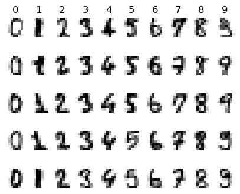

```python
# โหลด MNIST dataset จาก sklearn.dataset เก็บไว้ในตัวแปร digits
from sklearn import datasets
digits = datasets.load_digits()

# TODO: ตัดแบ่ง images และ target ออกเป็นส่วนชุด train และชุด test
# ให้ชุด train มีขนาด 1500 ภาพ
# ให้ชุด test มีขนาด 297 ภาพ
X_train = digits.images[:1500]
y_train = digits.target[:1500]
X_test = digits.images[1500:]
y_test = digits.target[1500:]

# ตรวจสอบความถูกต้องของขนาดข้อมูล
print('Training data shape: ', X_train.shape)
print('Training labels shape: ', y_train.shape)
print('Test data shape: ', X_test.shape)
print('Test labels shape: ', y_test.shape)

# visualize ตัวอย่างภาพจากแต่ละ class โดยสุ่ม class ละ 5 ภาพ
classes = [0,1,2,3,4,5,6,7,8,9]
num_classes = len(classes)
samples_per_class = 5
for y, cls in enumerate(classes):
    idxs = np.flatnonzero(y_train == y)
    idxs = np.random.choice(idxs, samples_per_class, replace=False)
    for i, idx in enumerate(idxs):
        plt_idx = i * num_classes + y + 1
        plt.subplot(samples_per_class, num_classes, plt_idx)
        plt.imshow(X_train[idx].astype('uint8'))
        plt.axis('off')
        if i == 0:
            plt.title(cls)
plt.show()
```

#### 2. ก่อนนำภาพไปใช้ train/test จะต้อง flatten ภาพจากขนาด 8 x 8 ให้กลายเป็นเวกเตอร์ขนาด 64

```python
X_train = X_train.reshape(-1, 64)
X_test = X_test.reshape(-1, 64)
```

#### 3. เรียกใช้ฟังก์ชัน train และ predict

```python
# TODO: ทดลองเปลี่ยนค่า k
train(X_train, y_train)
ypred = predict(X_test, k=4)
```

#### 4. คำนวณหา accuracy = อัตราส่วนของ label ที่ทำนายถูก

$ accuracy = \frac{\mbox{number of correct labels}}{\mbox{total number of predictions}} $

```python
# TODO: คำนวณค่าเหล่านี้
num_correct = sum(ypred == y_test)
num_test = len(y_test)
accuracy = num_correct/num_test
print('Got %d / %d correct => accuracy: %f' % (num_correct, num_test, accuracy))
```

```
Got 285 / 297 correct => accuracy: 0.959596
```

#### (เสริม) ทดสอบความถูกต้องของ compute_distances

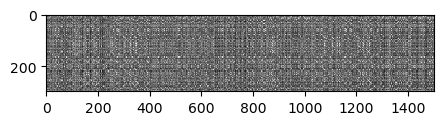

```python
dists = compute_distances(X_test)
plt.imshow(dists, interpolation='none')
plt.show()
```

**Question #1:** สังเกตว่าในภาพของ distance matrix จะมี pattern บาง row จะมีสีดำเป็นพิเศษ จงตอบคำถาม

- แถบ row ที่มีสีดำเกิดจากอะไรในข้อมูล จงอธิบายตามความเข้าใจ
- แถบ columns ที่มีสีดำเกิดจากอะไรในข้อมูล จงอธิบายตามความเข้าใจ

**ตอบ**: จุดที่มีสีดำพิเศษระหว่างแนว row(ภาพ test) กับแนว colunms(ภาพ train) จะแสดงถึงความมี distance ที่สูงระหว่างภาพ test และภาพ train เมื่อเทียบกันแล้วคู่ภาพ test/train นั้นมีลักษณะที่แตกต่างกัน ซึ่งก็คือเกิดจากเมื่อนำ Distance Metric ภาพแนวนอนจุดนั้นไปลบกับ Distance Metric ภาพแนวตั้งจุดนั้น และผลของการลบกันที่ได้มีค่าที่สูง จึงทำให้ฟังก์ชัน plt.inshow() แสดงจุดๆนั้นด้วยสีดำพิเศษ

**Question #2:** จงทดลองเปลี่ยนค่า k ตั้งแต่ 1..10 แล้วหาว่าค่า k ใดที่ทำให้ accuracy สูงที่สุด

**ตอบ**: 1 = 0.946128 ,2 = 0.956229 ,3 = 0.959596 ,4 = 0.959596 ,5 = 0.956229 ,6 = 0.946128 ,7 = 0.946128 ,8 = 0.942761 ,9 = 0.942761 ,10 = 0.942761

*ตอบ* = k ที่ 3 และ 4 มีค่า accuracy สูงที่สุด

### ทิ้งท้าย: อยากให้ test accuracy ของ kNN สูงขึ้น ต้องทำอย่างไร?

- สังเกตุว่าเราสามารถปรับแต่งหรือจูน **hyperparameter** ของ kNN ได้ เช่น
  - เปลี่ยนวิธีคำนวณระยะห่าง (L1 vs L2)
  - เปลี่ยนค่า k ที่ใช้
  - เปลี่ยนการให้น้ำหนักเพื่อนบ้านเวลา vote
- ในคาบเรียนสัปดาห์หน้าเราจะพบว่า
  - หากเลือก hyperparameter ไม่ดี อาจก่อให้เกิดปัญหา overfitting/underfitting ซึ่งจะส่งผลให้ค่า test accuracy ต่ำลง
  - เราสามารถใช้เทคนิค Grid Search ร่วมกับ Cross Validation ในการ tune ค่า hyperparameter เหล่านี้โดยอัตโนมัติได้